# Project 2

Katarzyna Kańska, Annanina Koster, Emilia Pompe

December 17, 2015

# Introduction

This project focuses on explaining what factors influence the length of dendritic spine, whose condition is believed to affect occurrence of several cognitive disorders.

We use the dataset `dendriticSpines.rda` with the study set to `gm`. This dataset contains `18716` observations of 5 mice’s lengths of dendritic spines.

```r
library(plyr)
load("dendriticSpines.rda")
```

The available variables in this dataset are

```
## [1] "Animal"       "Photo_ID_abs" "spine_number" "length"
## [5] "Study"        "mouse"        "treatment"
```

Treatments in our study are:

```
## dmso   gm
## 8922 9794
```

The mice are:

```
##    1    2    3    4    5
## 3263 3293 4383 2977 4800
```

The mouse ,,types’’ are:

```
##   TG   WT
## 9233 9483
```

which stands for

- WT (wild type) normal mice,
- TG (transgenic) mice with additional genetic material.

The way how spines are measured is following: from mouse ‘Animal ID’ the part (slice) of the brain is extracted. The slice is threated with treatment and then photos of slices are taken. Photo_ID_abs id the ID of the photo, note that this factor is nested in the Animal ID. In each photo different spines are visible. Length of spines visible on each photo is measured.

# The research objective

Explain what factors affect the length of spines. Pay special attention to checking for existence of an interaction between the mouse type and the treatment.

# Results

The final model we selected is described in the following table

| Variable name | Type of effect | Effect |
| --- | --- | --- |
| `mouse` | fixed | -0.13210 (WT) |
| `treatment` | fixed | -0.08661 (gm) |
| `mouse:treatment` | fixed (interaction term) | 0.11512 (WT:gm) |
| `Animal` | random | 0.03139 (Std.Dev.) |
| `Photo_ID_abs:Animal` | random (nested) | 0.11017 (Std.Dev.) |

We decided to set `mouse` and `treatment` as **fixed** effects because the number of levels of each of these variables is very small and we are interested in the precise value of estimators (they can be used for prediction).

Variable `Animal` is modeled as **random** effect because we don’t need to know the effect of certain animal, just the variation among the population of animals. The same argument is valid for `Photo_ID_abs` variable when we interpret this information in a way that different photo represents slightly different area of a brain.

# Statistical methods

## Graphical analysis

### `length` variable

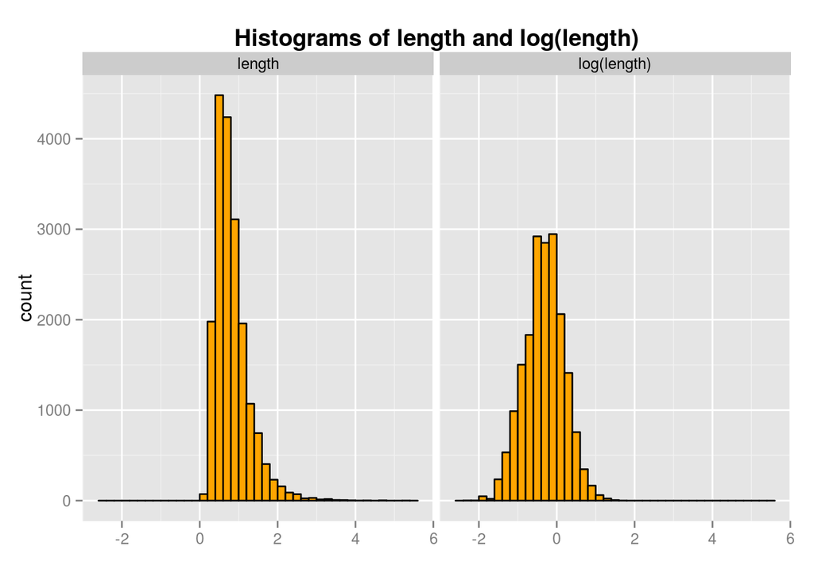

First thing we noticed were ‘’better’‘properties of distribution of logarithm of spines’ length. It is more similar to the normal distribution. So in further analysis we considered only `log(length)`.

### `treatment`, `mouse` and `Animal` variables

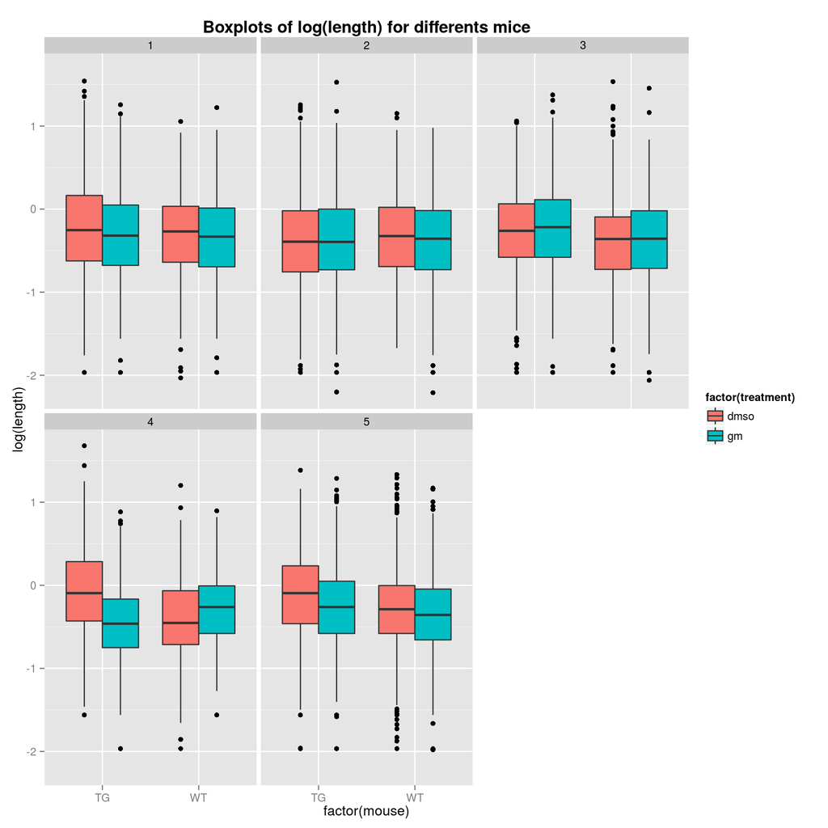

These boxplots suggests the existence of the `Animal` effect. For example, compare the effect of treatment for 3. and 4. transgenic mouse.

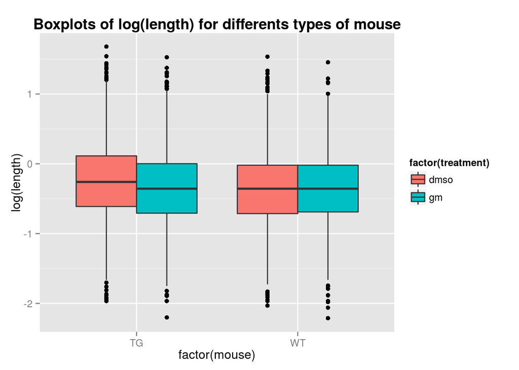

Here it seems that for transgenic mice the effect of dmso treatment is higher than for wild mice.

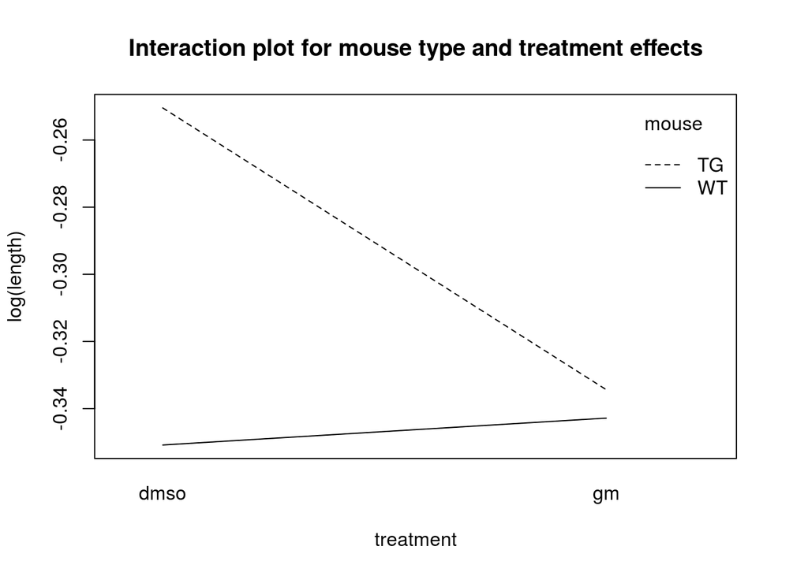

This plot convince us that there may exists an interaction between mouse type and treatment effect.

## Transformation of dependent variable `length`

We estimated several simple models considering only fixed and only random effects to check whether the `lenght` or the `log(length)` gives better results in terms of normality of residuals and estimated random effects. The `log(length)` definitely outperformed the `length`, so from now on we will only use this variable.

## Model selection - checking for interactions

Here we compared the models with and without the interactions between `mouse` and `treatment`.

```r
# mixed model with fixed effect without interaction
model2.1<- lmer(log(length) ~ factor(mouse) + factor(treatment) + (1|Animal/Photo_ID_abs), data=dendritic.data)
# normality tests
shapiro.test(ranef(model2.1)$`Photo_ID_abs:Animal`[,1]) # satisfied
```

```
##
##  Shapiro-Wilk normality test
##
## data:  ranef(model2.1)$`Photo_ID_abs:Animal`[, 1]
## W = 0.99477, p-value = 0.8213
```

```r
# mixed model with fixed effect with interaction
model3.1 <- lmer(log(length)~factor(mouse) * factor(treatment) + (1|Animal/Photo_ID_abs), data=dendritic.data)
# normality tests
shapiro.test(ranef(model3.1)$`Photo_ID_abs:Animal`[,1]) # satisfied
```

```
##
##  Shapiro-Wilk normality test
##
## data:  ranef(model3.1)$`Photo_ID_abs:Animal`[, 1]
## W = 0.99721, p-value = 0.9908
```

At this stage both of these models seem to be correct.

```r
anova(model2.1, model3.1)
```

```
## Data: dendritic.data
## Models:
## model2.1: log(length) ~ factor(mouse) + factor(treatment) + (1 | Animal/Photo_ID_abs)
## model3.1: log(length) ~ factor(mouse) * factor(treatment) + (1 | Animal/Photo_ID_abs)
##          Df   AIC   BIC logLik deviance  Chisq Chi Df Pr(>Chisq)
## model2.1  6 26799 26846 -13394    26787
## model3.1  7 26792 26847 -13389    26778 8.8379      1    0.00295 **
## ---
## Signif. codes:  0 '***' 0.001 '**' 0.01 '*' 0.05 '.' 0.1 ' ' 1
```

In terms of AIC and Log Likelihood criteria the model with interactions is slightly better, so it becomes our final model.

## Model validation

### Normality of random effects

```r
shapiro.test(ranef(model3.1, condVar=TRUE)$Animal[,1])
```

```
##
##  Shapiro-Wilk normality test
##
## data:  ranef(model3.1, condVar = TRUE)$Animal[, 1]
## W = 0.91324, p-value = 0.4873
```

```r
shapiro.test(ranef(model3.1, condVar=TRUE)$`Photo_ID_abs:Animal`[,1])
```

```
##
##  Shapiro-Wilk normality test
##
## data:  ranef(model3.1, condVar = TRUE)$`Photo_ID_abs:Animal`[, 1]
## W = 0.99721, p-value = 0.9908
```

The normality assumptions are fulfilled.

To be convinced, let us see the empirical distribution function.

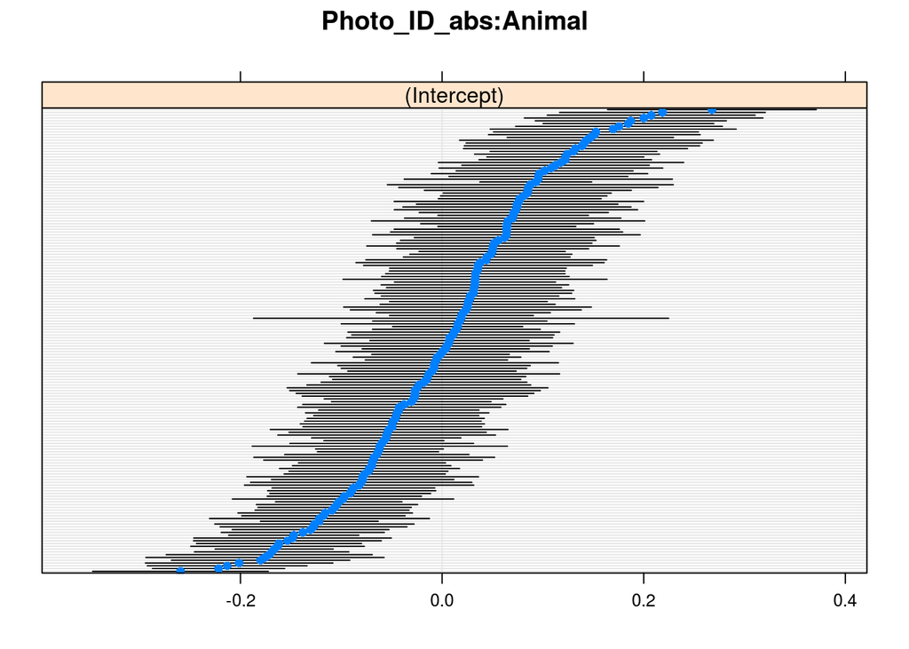

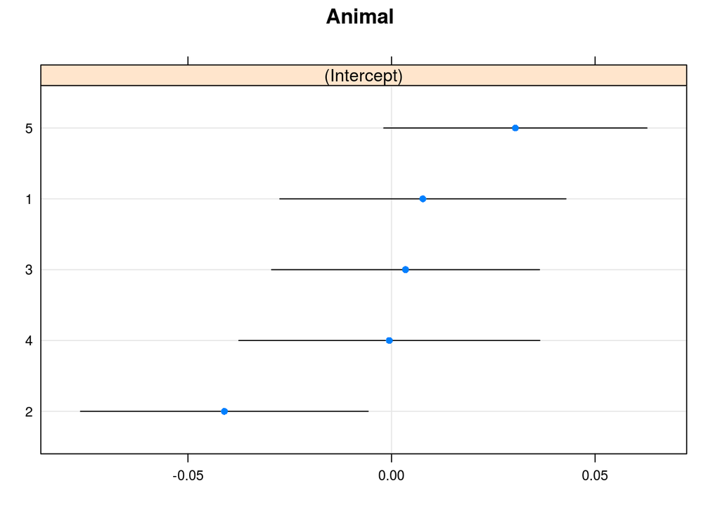

Especially the plot for `Photo_ID_abs` is very similar to the normal cumulative distribution function. To make sure, let us also have a look at a qq-plot:

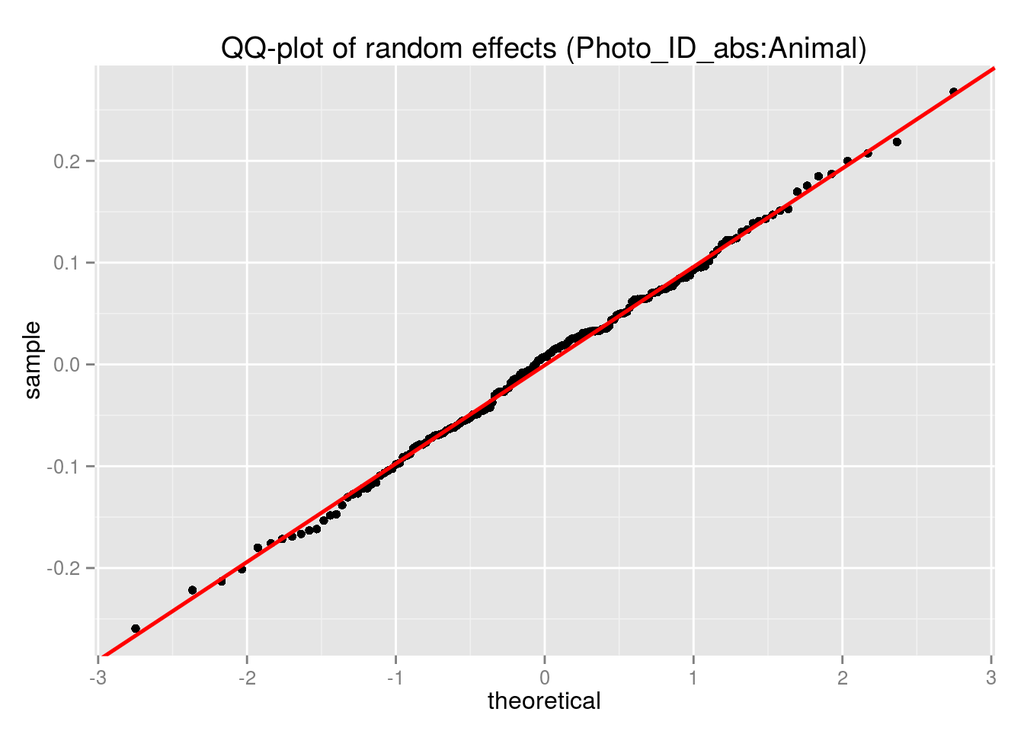

### Normality of residuals

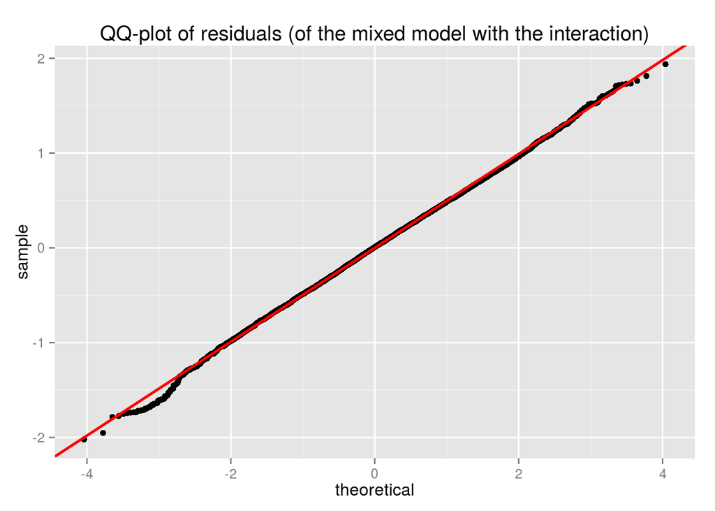

```
##
## Title:
##  Jarque - Bera Normalality Test
##
## Test Results:
##   STATISTIC:
##     X-squared: 14.4132
##   P VALUE:
##     Asymptotic p Value: 0.0007417
##
## Description:
##  Thu Dec 17 00:10:01 2015 by user:
```

The QQ plot indicates that residuals are normally distributed. The Jarque–Bera test for normality gives a small p-value, but taking into consideration the data size (many observations) we can interpret the result as positive, that is not rejecting the null hypothesis of normality.

### Homogenity of variance for residuals

```r
d <- data.frame(residuals = residuals(model3.1),
                mouse = dendritic.data$mouse,
                treatment = dendritic.data$treatment)
ddply(d, .(mouse, treatment), summarize,
 var = var(residuals))
```

```
##   mouse treatment       var
## 1    TG      dmso 0.2724610
## 2    TG        gm 0.2399026
## 3    WT      dmso 0.2309504
## 4    WT        gm 0.2165629
```

The variances calculated for groups seem to be very similar.

### Independence of epsilons and random effects

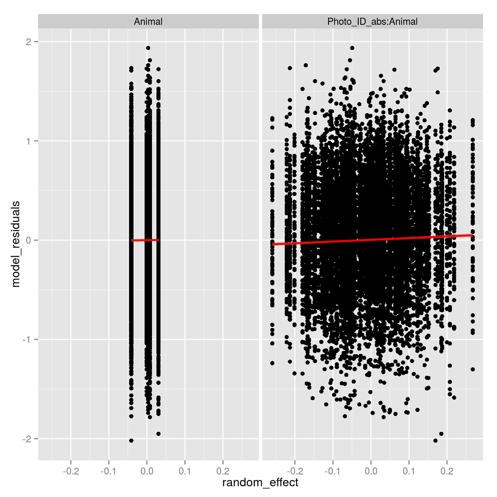

```r
u <- ranef(model3.1, condVar = TRUE)
e <- residuals(model3.1)
# v contains a random effect for Animal
v <- u$Animal[,1][dendritic.data$Animal]

# w contains a 'nested' random effect for Photo
w <- u$`Photo_ID_abs:Animal`[paste0(dendritic.data$Photo_ID_abs,":",dendritic.data$Animal),1]

d <- data.frame(model_residuals=c(e,e), random_effect=c(v,w),
                type=rep(c("Animal", "Photo_ID_abs:Animal"), each=nrow(dendritic.data)))
ggplot(d, aes(x=random_effect, y=model_residuals)) + geom_point() + geom_smooth(method="lm", col="red", size=1)+
  facet_wrap(~type)
```

Epsilons and random effects seem to be independent as we cannot see any pattern in these plots.

### Wald test for fixed effects

```r
tse <- summary(model3.1)$coefficients[,3]
2*pnorm(tse[tse<0], lower.tail=T)
```

```
##         (Intercept)     factor(mouse)WT factor(treatment)gm
##        5.629212e-21        1.784492e-06        1.397698e-03
```

```r
2*pnorm(tse[tse>0], lower.tail=F)
```

```
## factor(mouse)WT:factor(treatment)gm
##                         0.002673431
```

All of the coefficients turned out to be significant, including the interaction.

### Significance of mixed effects

We compare Log Likelihoods for models with and without random effects.

```r
model0.1 <- lm(log(length)~factor(mouse)*factor(treatment), data=dendritic.data)
lL0 <- logLik(model0.1)
lL3 <- logLik(model3.1)
df0 <- attr(logLik(model0.1),"df")
df3 <- attr(logLik(model3.1),"df")

lDelta <- as.numeric(lL0-lL3)
df <- as.numeric(df3-df0)

pchisq(-2*lDelta, df, lower.tail=F)
```

```
## [1] 7.650657e-134
```

The difference is significant. We tested also whether our model with a nested random effect is significantly better than the one with a random effect of Animal only.

```r
model3.1.1 <-lmer(log(length)~factor(mouse) * factor(treatment) + (1|Animal), data=dendritic.data)
anova(model3.1.1,model3.1)
```

```
## Data: dendritic.data
## Models:
## model3.1.1: log(length) ~ factor(mouse) * factor(treatment) + (1 | Animal)
## model3.1: log(length) ~ factor(mouse) * factor(treatment) + (1 | Animal/Photo_ID_abs)
##            Df   AIC   BIC logLik deviance  Chisq Chi Df Pr(>Chisq)
## model3.1.1  6 27333 27380 -13661    27321
## model3.1    7 26792 26847 -13389    26778 542.78      1  < 2.2e-16 ***
## ---
## Signif. codes:  0 '***' 0.001 '**' 0.01 '*' 0.05 '.' 0.1 ' ' 1
```

A random effect of Photo turned out to be significant.

[figure not shown]

**MERRY CHRISTMAS!**